# Grupo II - Avaliação de indicadores de práticas de saúde em relação a variáveis socioeconômicas

# 5.25 Indicadores de educação de saude nas escolas e indicadores socioeconômicos

## Educação sanitária X IDHM

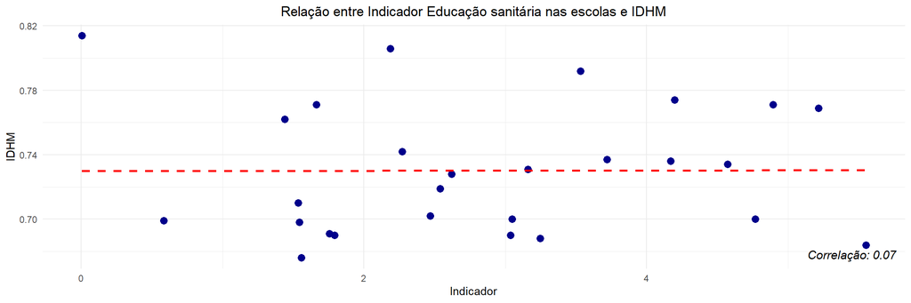

## Educação Sanitária X Indice de GINI

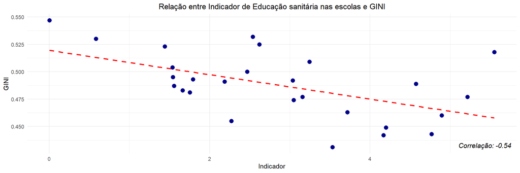

## Educação Sanitária X PIB

[figure not shown]

## Educação Sanitária X IVS

[figure not shown]

# 5.23 Indicadores de Saude nas escolas e indicadores socioeconômicos

## Saúde X IDHM

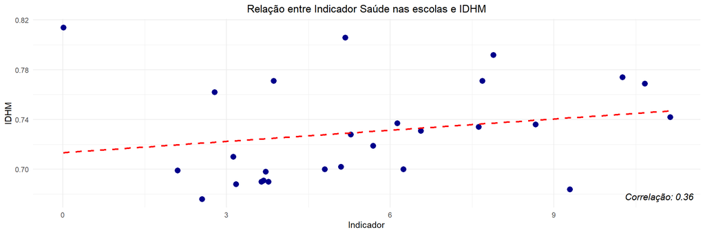

## Saude nas escolas X Indice de GINI

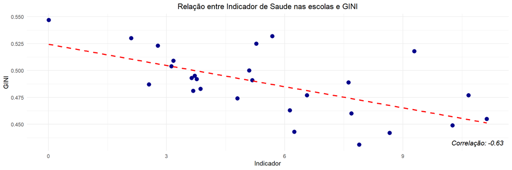

[figure not shown]

[figure not shown]

# 5.24 Relação percentual de cobertura acompanhados BF e indicadores socioeconômicos

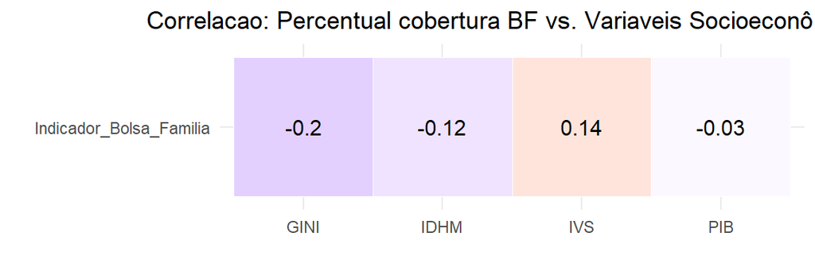

# 5.26 Indicadores cobertura BF e indicadores socioeconômicos

## Cobertura Bolsa Familia X IDHM

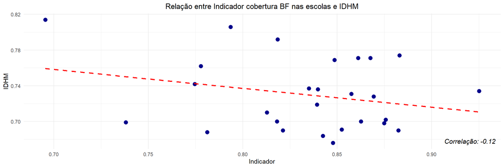

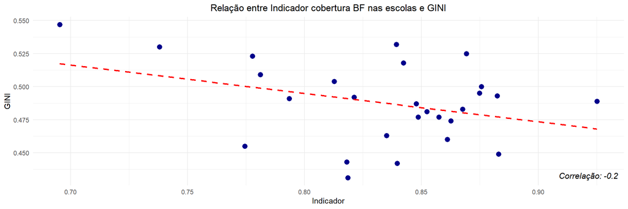

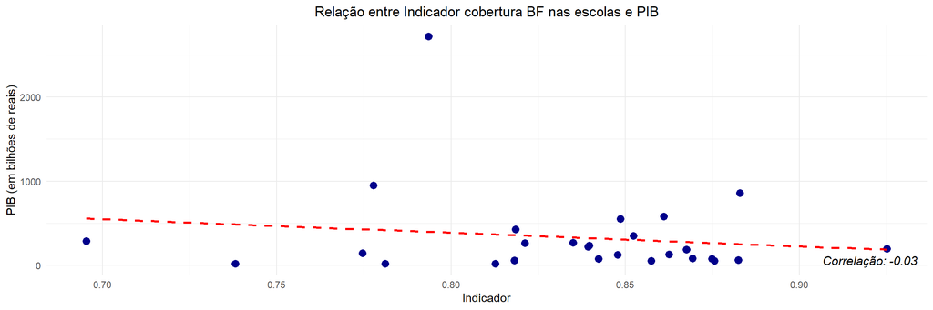

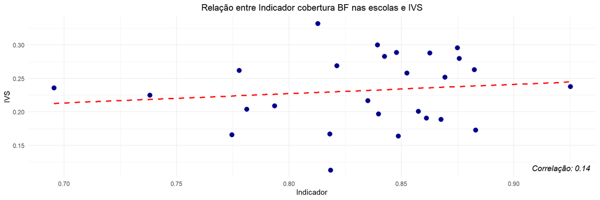

# 6 Referencias Bibliográficas

- VIEIRA, Sonia. Bioestatística: Tópicos avançados. 4ª edição. Rio de Janeiro: Elsevier, 2018.
- Heidmann, Ivonete T.S. Buss, Almeida, Maria Cecília Puntel de. Boehs, Astrid Eggert. HEIDMANN, Ivonete T.S.; BUSS, Almeida, Maria Cecília Puntel de; BOEHS, Astrid Eggert; WOSNY, Antonio de Miranda; MONTICELLI, Marisa. Promoção à saúde: Trajetória histórica de suas concepções. Texto Contexto Enferm, v. 15, n. 2, p. 352-358, 2006.
- BUSS, Paulo Marchiori; HARTZ, Zulmira Maria de Araújo; PINTO, Luiz Felipe; ROCHA, Cristianne Maria Famer. Promoção da saúde e qualidade de vida: uma perspectiva histórica ao longo dos últimos 40 anos (1980-2020). Ciência & Saúde Coletiva, v. 25, n. 12, p. 4723-4735, 2020.
- Pinheiro ES, Alcântara CS, Sobral TC, Silva SS, Lima JS, Carvalho DO, et al. Promoção à saúde em serviço de diabetes e hipertensão. REVISA. 2023; 12(Esp1): 671-80.